# Predict the Survival on the Titanic

Liu Chaoran

11 June 2015

## Ojectives:

Given some incompleted passenger information:  
1. Find out what sorts of people were likely to survive.  
2. Predict which passengers survived the tragedy.

## Description of Data:

**Survival:** Survival (0 = No; 1 = Yes)  
**Pclass:** Passenger Class (1 = 1st; 2 = 2nd; 3 = 3rd)  
**Name:** Name  
**Sex:** Sex  
**Age:** Age  
**Sibsp:** Number of Siblings/Spouses Aboard  
**Parch:** Number of Parents/Children Aboard  
**Ticket:** Ticket Number  
**Fare:** Passenger Fare  
**Cabin:** Cabin  
**Embarked:** Port of Embarkation

```r
summary(train)
```

```
##   PassengerId       Survived          Pclass          Name
##  Min.   :  1.0   Min.   :0.0000   Min.   :1.000   Length:891
##  1st Qu.:223.5   1st Qu.:0.0000   1st Qu.:2.000   Class :character
##  Median :446.0   Median :0.0000   Median :3.000   Mode  :character
##  Mean   :446.0   Mean   :0.3838   Mean   :2.309
##  3rd Qu.:668.5   3rd Qu.:1.0000   3rd Qu.:3.000
##  Max.   :891.0   Max.   :1.0000   Max.   :3.000
##
##      Sex                 Age            SibSp           Parch
##  Length:891         Min.   : 0.42   Min.   :0.000   Min.   :0.0000
##  Class :character   1st Qu.:20.12   1st Qu.:0.000   1st Qu.:0.0000
##  Mode  :character   Median :28.00   Median :0.000   Median :0.0000
##                     Mean   :29.70   Mean   :0.523   Mean   :0.3816
##                     3rd Qu.:38.00   3rd Qu.:1.000   3rd Qu.:0.0000
##                     Max.   :80.00   Max.   :8.000   Max.   :6.0000
##                     NA's   :177
##     Ticket               Fare           Cabin             Embarked
##  Length:891         Min.   :  0.00   Length:891         Length:891
##  Class :character   1st Qu.:  7.91   Class :character   Class :character
##  Mode  :character   Median : 14.45   Mode  :character   Mode  :character
##                     Mean   : 32.20
##                     3rd Qu.: 31.00
##                     Max.   :512.33
##
```

## Intuition:

1. Female and Children are likely to have piority to board the lifeboat.
2. Rich/Noble poeple may have some previlege.
3. Big family may have difficulty to gather all family members to evacuate.

## Approach:

1. Exploratory Data Analysis
2. Feature Creation
3. Deal with Incomplete Data
4. Apply Machine Learning Models
5. Findings

## Exploratory Data Analysis:

### 1. Effect on Age

Passenger Age distribution is close to normal distribution.  
Children (<12 years old) have bigger change to survive.

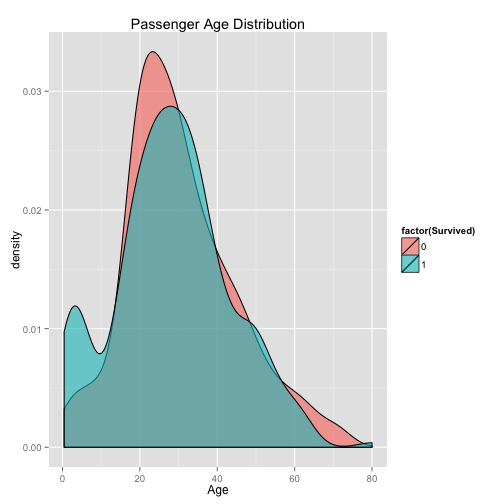

```r
ggplot(subset(train,Age!=is.na(Age)),aes(x=Age,fill=factor(Survived)))+geom_density(alpha=0.6)+labs(title='Passenger Age Distribution')
```

### 2. Effect on Fare

Fare has a skewed distribution, majority has the Fare < $50.  
There is higher change of perishing, for those with Fare < $20.

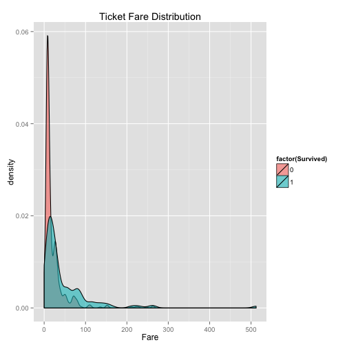

```r
ggplot(train,aes(x=Fare,fill=factor(Survived)))+geom_density(alpha=0.6,na.rm=TRUE)+labs(title='Ticket Fare Distribution')
```

### 3. Effect on Pclass

Higher Passenger class implies higher surival rate.

### 4. Effect on Sex

Female has higher survival rate.

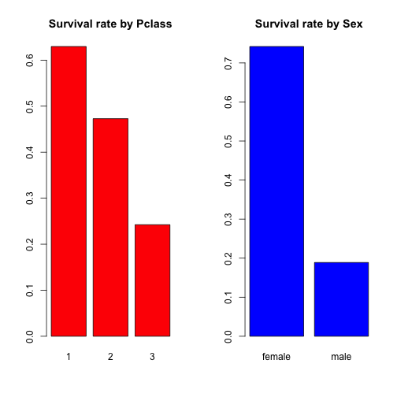

```r
byPclass<-aggregate(Survived~Pclass,train,mean)
bySex<-aggregate(Survived~Sex,train,mean)
par(mfrow=c(1,2))
barplot(byPclass$Survived,names.arg=byPclass$Pclass,col='red',main='Survival rate by Pclass')
barplot(bySex$Survived,names.arg=bySex$Sex,col='blue',main='Survival rate by Sex')
```

## Binding train/test Data for Pre-Processing

```r
train$Cat<-'train'
test$Cat<-'test'
test$Survived<-NA
full<-rbind(train,test)
```

## Feature Creation:

### 1. Extract Title from Name

Passenger Names are in format of Surname, Title. Firstname

```r
full$Name[1]
```

```
## [1] "Braund, Mr. Owen Harris"
```

Split the text to get Title

```r
full$Title<-sapply(full$Name,function(x) strsplit(x,'[.,]')[[1]][2])
full$Title<-gsub(' ','',full$Title)
table(full$Title)
```

```
##
##        Capt         Col         Don        Dona          Dr    Jonkheer
##           1           4           1           1           8           1
##        Lady       Major      Master        Miss        Mlle         Mme
##           1           2          61         260           2           1
##          Mr         Mrs          Ms         Rev         Sir theCountess
##         757         197           2           8           1           1
```

Aggregate some less frequent Titles

```r
full$Title[full$Title %in% c('Capt', 'Don', 'Major','Jonkheer')] <- 'Sir'
full$Title[full$Title %in% c('Dona','the Countess' )] <- 'Lady'
full$Title[full$Title %in% c('Mlle','Mme','Ms')] <- 'Miss'
```

### 2. Adding FamilySize

FamilySie = Parch (No.of Parents/Children) + SibSp (No. of Sibling/Spouse)+1

```r
full$FamilySize<-full$Parch+full$SibSp+1
```

### 3. Adding Mother

characterize mother as female who are older than 18 years old and travelled with child

```r
full$Mother<-0
full$Mother[full$Sex=='female' & full$Parch>0 & full$Age>18 & full$Title!='Miss']<-1
```

### 4. Adding Child

characterize child as who are not older than 12 years old

```r
full$Child<-0
full$Child[full$Parch>0 & full$Age<=12]<-1
```

## Deal with Missing Data:

### checking the missing data

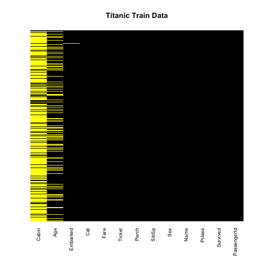

```r
library(Amelia)
missmap(train,col=c('yellow','black'),main='Titanic Train Data',legend=F,y.labels=NULL,y.at=NULL)
```

Cabin, Age, and Embarked are identified with missing values.

### 1. Embarked

Only two Embarked are missing, simply assign them to the majority.

```r
table(full$Embarked)
```

```
##
##   C   Q   S
## 270 123 914
```

```r
full$Embarked[is.na(full$Embarked)]<-'S'
```

### 2. Age

```r
library(rpart)
fit.Age<-rpart(Age~Pclass+Title+Sex+SibSp+Parch+Fare,data=subset(full,Age!=is.na(Age)),method='anova')
full$Age[is.na(full$Age)]<-predict(fit.Age,full[is.na(full$Age),])
```

### 3. Cabin

Over 70% is missing, predicting cabin here may be inappropiate.  
Hence cabin information is ignored at this stage of analysis.

## Split into train/test data

```r
train<-full[full$Cat=='train',]
test<-full[full$Cat=='test',]
train$Survived<-factor(train$Survived)
#levels(train$Survived)<-c('Perished','Survived')
```

## Apply Mahcine Learning Models:

To evaluate different models, 10 folds repeated cv is used.  
Selection metrics is accuracy.

```r
library(caret)
control=trainControl(method='repeatedcv',number=10,repeats=10)
```

### Bayesian Logisitic Regression

```r
set.seed(99)
fit.bl<-train(Survived~FamilySize+Pclass+Sex+Age+SibSp+Parch+Fare+Embarked+Title+Mother+Child,data=train,method='bayesglm',trControl=control,family=binomial(link='logit'))
```

### Decision Tree

```r
set.seed(99)
fit.rp<-train(Survived~FamilySize+Pclass+Sex+Age+SibSp+Parch+Fare+Embarked+Title+Mother+Child,data=train,method='rpart',trControl=control)
```

### Random Forest

```r
set.seed(99)
fit.rf<-train(Survived~FamilySize+Pclass+Sex+Age+SibSp+Parch+Fare+Embarked+Title+Mother+Child,data=train,method='rf',trControl=control)
```

### Neural Network

```r
set.seed(99)
fit.nnet<-train(Survived~FamilySize+Pclass+Sex+Age+SibSp+Parch+Fare+Embarked+Title+Mother+Child,data=train,method='nnet',trControl=control,maxit=1000,trace=F,tuneGrid=grid.nnet)
```

## Compare the Prediction:

Nerual Network is the best in terms of accuracy with 10 folds cross validation.

```r
acc.bl<-paste0(round(max(fit.bl$results$Accuracy),4)*100,'%')
acc.rp<-paste0(round(max(fit.rp$results$Accuracy),4)*100,"%")
acc.rf<-paste0(round(max(fit.rf$results$Accuracy),4)*100,"%")
acc.nnet<-paste0(round(max(fit.nnet$results$Accuracy),4)*100,'%')
```

List the accuracy for different models:  
Bayesian Logistic Regression: 82.68%  
Decision Tree: 81.22%  
Random Frost: 82.76%  
Neural Network: 82.85%

## Write submission using Neural Network:

```r
test$Survived<-predict(fit.nnet,test)
submission<-test[,1:2]
write.csv(submission,'submission.csv',row.names=F)
```

## Findings:

**The most likely to survive on the Titanic are:**  
Pclass 1 & 2 female and children. (95% survived)  
**The most unlikely to survive on the Titanic are:**  
Pclass 3 female/children with family size bigger than 4. (only 9% survived)

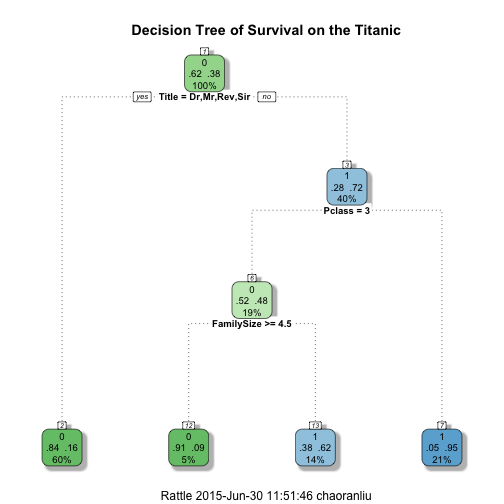

```r
library(rpart)
fit.rpart<-rpart(Survived~FamilySize+Pclass+Sex+Age+SibSp+Parch+Fare+Embarked+Title+Mother+Child,data=train,control=rpart.control(cp=0.01))
library(rattle)
fancyRpartPlot(fit.rpart,main='Decision Tree of Survival on the Titanic',cex=0.8)
```